# Bayesian estimation with simple disease models

### Disease model with multiple parameters

Now, let’s expand this a bit and try a disease model with multiple parameters.

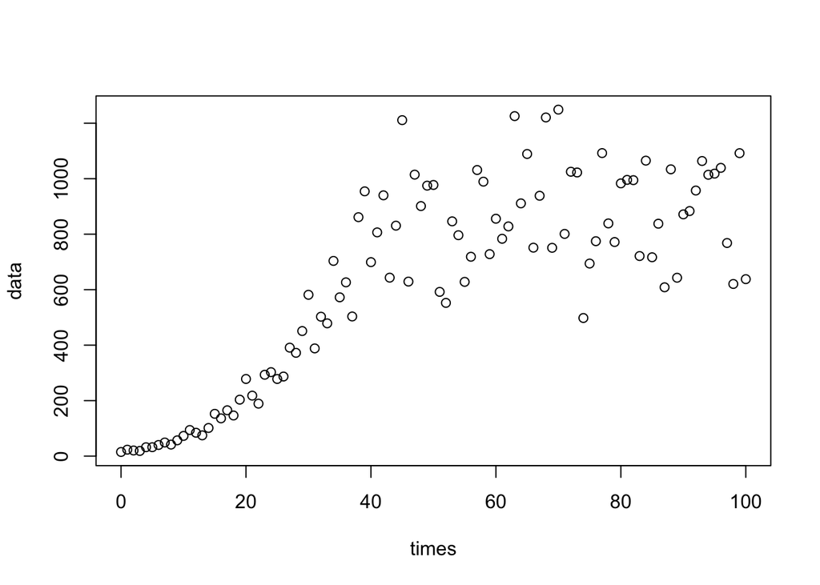

```r
#### SI model ####
SIode = function(t, x, params){
  S = x[1]
  I = x[2]

  b = params[1]
  g = params[2]

  dS = -b*S*I + g*I
  dI = b*S*I - g*I

  list(c(dS, dI))
}

#### Measurement equation ####
yfun = function(x,params){x[,3]*10000*params[3]}

#### Simulate data ####
times = seq(0,100,1)
trueparams = c(0.25,0.1,0.15)
xsimdata = ode(c(0.99,0.01), times, SIode, trueparams, method='ode45')
data = rnorm(length(times),yfun(xsimdata,trueparams),0.2*yfun(xsimdata,trueparams))
plot(times,data)
```

Now, we can make the likelihood function, which is the same normal distribution setup we used to generate the data, but now viewed as a function of the parameters with the data fixed.

```r
loglike = function(par){
  xtemp = ode(c(0.99,0.01), times, SIode, par, method='ode45')
  return(sum(dnorm(data, yfun(xtemp,par), 0.2*yfun(xtemp,par), log = T)))
}
```

Lastly, let’s run the MCMC—for our priors, let’s take uniform distributions between $0$ and $0.5$ for all the parameters (you can play with this to make something a little more realistic if you want).

```r
setup = createBayesianSetup(likelihood = loglike, lower = c(0,0,0), upper = c(0.5,0.5,0.5))
settings = list(iterations = 10000, message=F)

res = runMCMC(bayesianSetup = setup, settings = settings)
summary(res)
```

```
## # # # # # # # # # # # # # # # # # # # # # # # # #
## ## MCMC chain summary ##
## # # # # # # # # # # # # # # # # # # # # # # # # #
##
## # MCMC sampler:  DEzs
## # Nr. Chains:  3
## # Iterations per chain:  3334
## # Rejection rate:  0.801
## # Effective sample size:  375
## # Runtime:  31.972  sec.
##
## # Parameter       MAP      2.5%    median   97.5%
## #  par 1 :       0.259    0.229    0.262    0.296
## #  par 2 :       0.123    0.065    0.127    0.160
## #  par 3 :       0.170    0.112    0.172    0.199
##
## ## DIC:  2.034332e+27
## ## Convergence
##  Gelman Rubin multivariate psrf:
##
## ## Correlations
##       par 1 par 2 par 3
## par 1 1.000 0.660 0.374
## par 2 0.660 1.000 0.792
## par 3 0.374 0.792 1.000
```

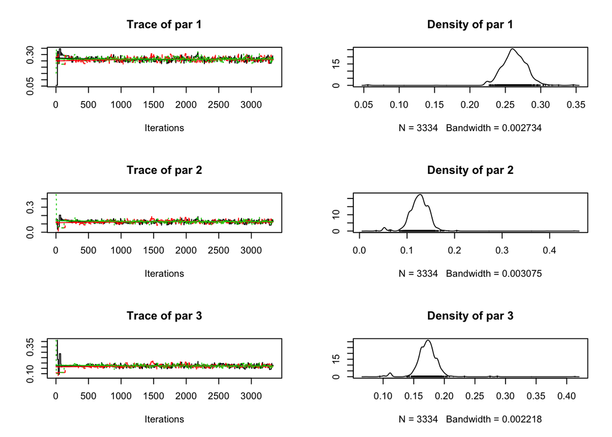

```r
plot(res)
```

Based on this, it looks like we’re reasonably well burned in after roughly 1000 iterations. Let’s plot the marginal parameter densities starting from there:

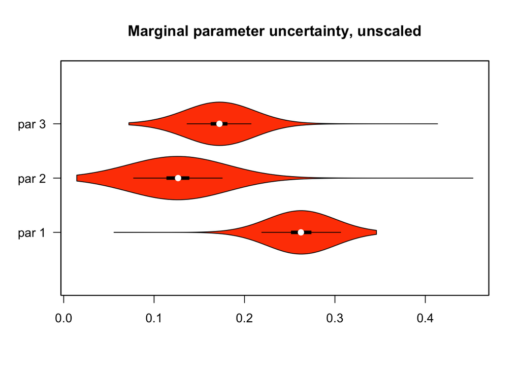

```r
marginalPlot(res, start=1000)
```

We may also want to examine the correlations between parameters (this can also help inform us about the identifiability of the parameters):

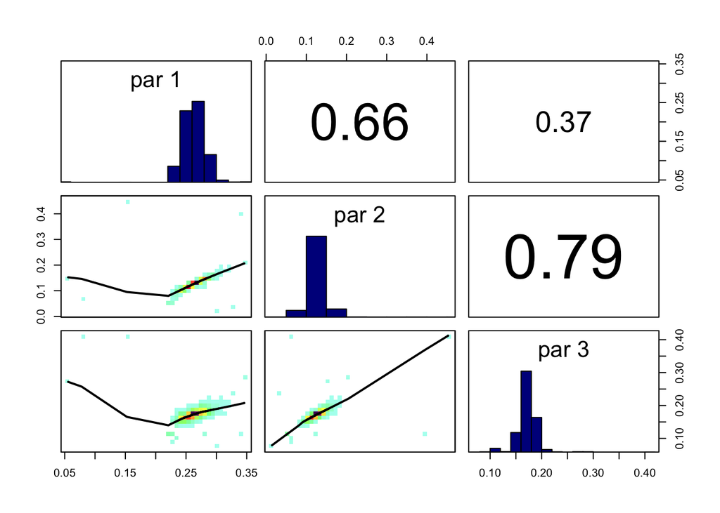

```r
correlationPlot(res)
```

### Examining the model fit

Now, the default plots don’t actually tell us how well the model is fitting the data, so let’s take a look. First, we can simulate and plot the model using the maximum *a posteriori* parameter values:

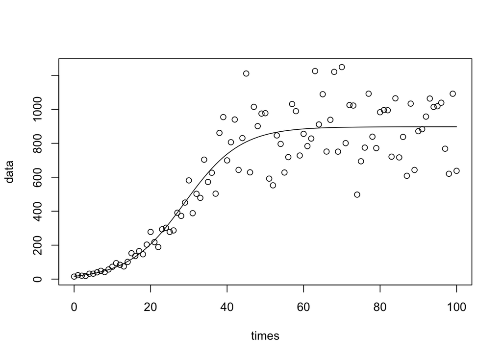

```r
mapests = MAP(res) # MAP generates a list with the MAP parameter estimates, and the associated posterior, likelihood, and prior.

xmap = ode(c(0.99,0.01), times, SIode, mapests$parametersMAP)
plot(times,data)
lines(xmap[,1],yfun(xmap,mapests$parametersMAP),type='l')
```

Looks pretty good! But we should also look at the effect of the uncertainty in the parameters. Let’s pull a sample of 1000 values from our chain and plot the model behavior for each sampled parameter set:

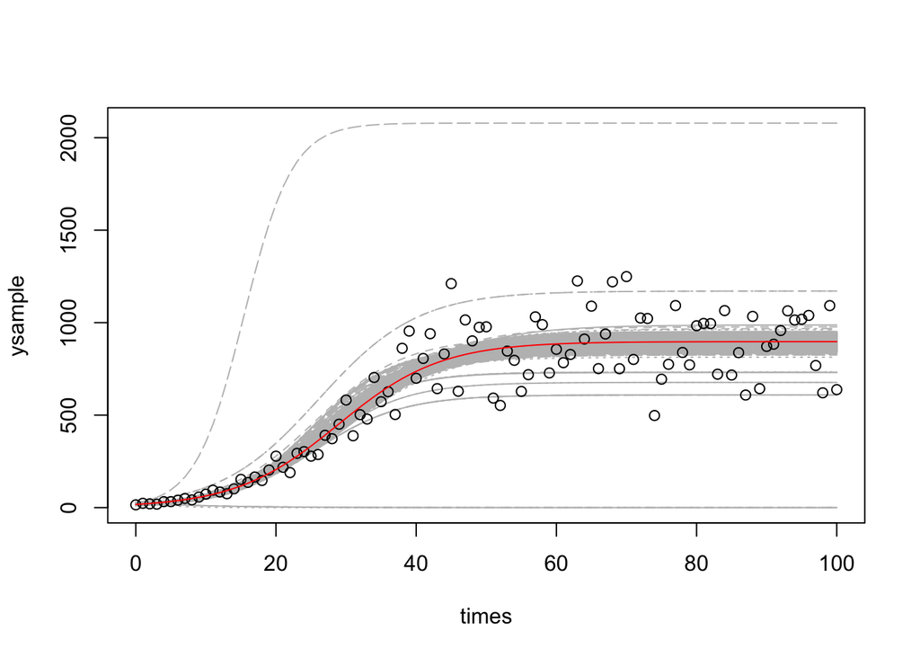

```r
# Pull a sample of 1000 parameter sets from our Markov chain
paramsample = getSample(res, parametersOnly = F, numSamples = 1000)

# We're going to run the model for each parameter set,
# and save the output y to ysample
ysample = matrix(0,length(times),length(paramsample[,1]))
for(i in 1:length(paramsample[,1])){
  xtemp = ode(c(0.99,0.01), times, SIode, paramsample[i,1:3])
  ysample[,i] = yfun(xtemp,paramsample[i,1:3])
}

# Now let's plot!
matplot(times,ysample,type='l',col="grey") # sample trajectories
points(times,data) # data
lines(xmap[,1],yfun(xmap,mapests$parametersMAP),type='l',col='red') # MAP estimate
```

To make this a little cleaner, we can/should also make credible intervals—see the *Other things to try* section below.

### Different Priors

We can generate a prior using some of the pre-built functions in `BayesianTools`, or if you want, you can make your own from scratch (you just have to give `BayesianTools` a density function (like `dnorm`) and a sampler (like `rnorm`)). Let’s try using a truncated normal distribution:

```r
newprior = createTruncatedNormalPrior(mean = rep(0.5,3), sd = rep(5,3), lower = rep(0,3), upper = c(2,2,1))
bayesianSetup = createBayesianSetup(likelihood = loglike, prior = newprior)
```

Now we could run this just like before, with `runMCMC`. Alternatively, we might want to take the posterior of our estimation, and use it as the prior for a new run (for example, if are getting new data). In that case, we can use:

```r
newprior = createPriorDensity(res, method = "multivariate", eps = 1e-10, lower = rep(0,3), upper =  rep(1,3), best = NULL)
bayesianSetup = createBayesianSetup(likelihood = loglike, prior = newprior)
```

### Other Things to Try

- Try some different sampling methods—which ones are faster/slower? How does the chain convergence go for each one?
- Try out making credible intervals for your model prediction—you can do this by taking a sample from your chain, and then, for example, taking the top 95% of samples (where ‘best’ is measured by the posterior density) and simulating the model trajectory for just those. This range should approximate the credible interval.
- Try making the model unidentifiable (e.g. make $\beta = \beta_1 \beta_2$), and see how that affects the estimation.
- Try the above code but with a more realistic, larger model. Try out a model you’ve been working on, and/or try it out with our Yemen case study.
- If you are familiar with Gillespie’s algorithm (or Tau-leaping, or any other method for making a stochastic SIR-type model), try out using a stochastic model instead of a deterministic one! (Note this may be somewhat slow! You might need to reduce the number of iterations while you’re debugging your code.)

### Useful References

- [Some vignettes from the package documentation](https://cran.r-project.org/web/packages/BayesianTools/vignettes/BayesianTools.html#the-different-mcmc-samplers) - includes tutorial examples and illustrates how to use different sampling methods.
- [A nice, short blog post with a quick introduction](https://theoreticalecology.wordpress.com/2017/10/05/the-bayesiantools-r-package-with-general-purpose-mcmc-and-smc-samplers-for-bayesian-statistics/)
- [More vignettes](https://rdrr.io/cran/BayesianTools/f/vignettes/BayesianTools.Rmd)